# Demos for canprot

The **canprot** package calculates chemical metrics of proteins from amino acid compositions. This vignette was compiled on 2024-03-28 with **canprot** version 2.0.0.

Next vignette: Introduction to canprot

## canprot demo #1: Thermophiles

Run the demo using `demo("thermophiles")`. For this demo, just the output is shown below.

The **canprot** functions used are:

- `calc_metrics()`: Calculates metrics named in an argument. The metrics calculated here are:
  - `S0g`: standard specific entropy
  - `Zc`: carbon oxidation state
- `cplab`: This is not a function, but an object that has formatted text labels for each metric.
- `add_hull()`: Adds a convex hull around data points

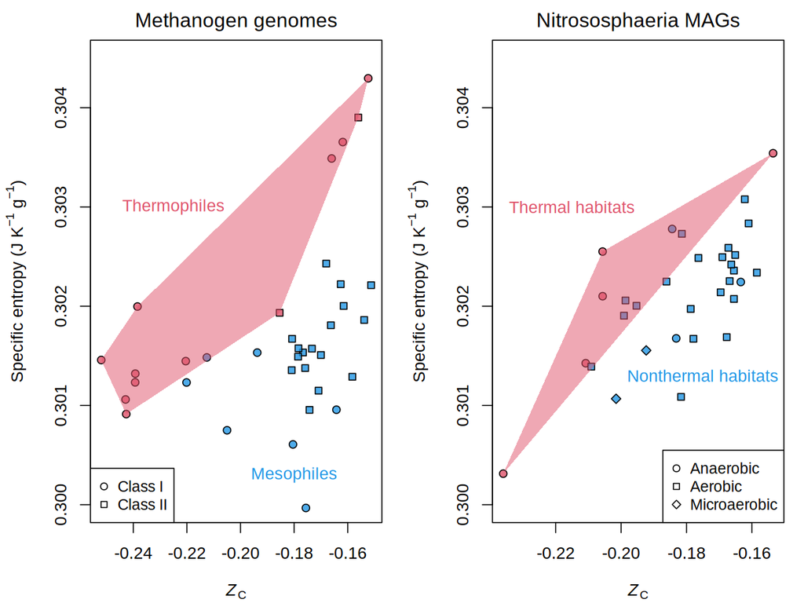

The data are from Dick et al. (2023) for methanogen genomes (amino acid composition and optimal growth temperature) and from Luo et al. (2024) for *Nitrososphaeria* MAGs (genome assemblies and habitat and respiration types). The plots reveal that proteins tend to have higher specific entropy in thermophilic genomes and MAGs from thermal habitats compared to mesophilic genomes and MAGs from nonthermal habitats, for a given carbon oxidation state. This implies that, after correcting for *Z*<sub>C</sub>, proteins in thermophiles have a more negative derivative of the standard Gibbs energy per gram of protein with respect to temperature.

## canprot demo #2: Subcellular locations

Run the demo using `demo("locations")`. The code and output of the demo are shown below.

The **canprot** functions used are:

- `human_aa()`: Gets amino acid compositions of human proteins from UniProt IDs
- `plength()`: Calculates protein length (this line is commented out)
- `Zc()`: Calculates carbon oxidation state
- `pI()`: Calculates isoelectric point
- `add_cld()`: Adds compact letter display to a boxplot

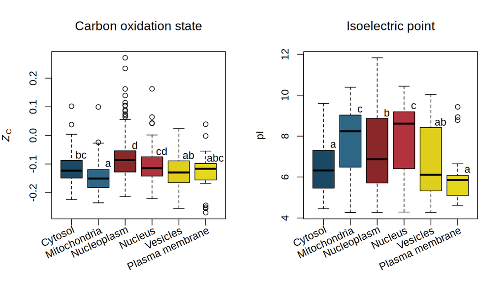

```r
# Read SI table
file <- system.file("extdata/protein/TAW+17_Table_S6_Validated.csv", package = "canprot")
dat <- read.csv(file)
# Keep only proteins with validated location
dat <- dat[dat$Reliability == "Validated", ]
# Keep only proteins with one annotated location
dat <- dat[rowSums(dat[, 4:32]) == 1, ]

# Get the amino acid compositions
aa <- human_aa(dat$Uniprot)
# Put the location into the amino acid data frame
aa$location <- dat$IF.main.protein.location

# Use top locations (and their colors) from Fig. 2B of Thul et al., 2017
locations <- c("Cytosol","Mitochondria","Nucleoplasm","Nucleus","Vesicles","Plasma membrane")
col <- c("#194964", "#2e6786", "#8a2729", "#b2333d", "#e0ce1d", "#e4d71c")
# Keep the proteins in these locations
aa <- aa[aa$location %in% locations, ]
## Keep only proteins with length between 100 and 2000
#aa <- aa[plength(aa) >= 100 & plength(aa) <= 2000, ]

# Get amino acid composition for proteins in each location
# (Loop over groups by piping location names into lapply)
aalist <- lapply(locations, function(location) aa[aa$location == location, ] )

# Setup plot
par(mfrow = c(1, 2))
titles <- c(Zc = "Carbon oxidation state", pI = "Isoelectric point")
# Calculate Zc and pI
for(metric in c("Zc", "pI")) {
  datlist <- lapply(aalist, metric)
  bp <- boxplot(datlist, ylab = cplab[[metric]], col = col, show.names = FALSE)
  add_cld(datlist, bp)
  # Make rotated labels
  x <- (1:6) + 0.1
  y <- par()$usr[3] - 1.5 * strheight("A")
  text(x, y, locations, srt = 25, adj = 1, xpd = NA)
  axis(1, labels = FALSE)
  title(titles[metric], font.main = 1)
}
```

The plots show carbon oxidation state (*Z*<sub>C</sub>) and isoelectric point (pI) for human proteins in different subcellular locations. The localization data is from Table S6 of Thul et al. (2017), filtered to include proteins that have both a validated location and only one predicted location.

## canprot demo #3: Redoxins

Run the demo using `demo("redoxins")`. For this demo, just the output is shown below.

The **canprot** functions used are:

- `read_fasta()`: Reads a FASTA sequence file and returns amino acid compositions of proteins. Additional processing is performed by using the following arguments:
  - `type` to read header lines
  - `iseq` to read specific sequences
  - `start` and `stop` to read segments of the sequences
- `Zc()`: Calculates carbon oxidation state

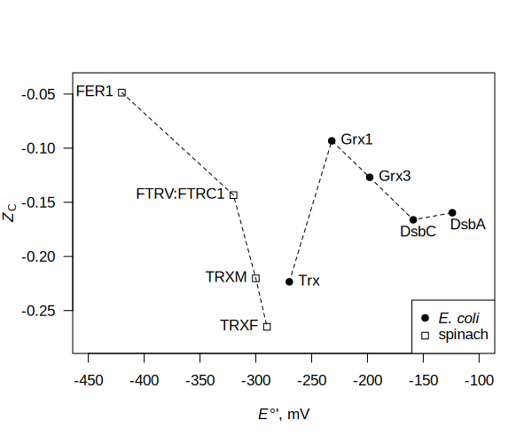

This is an *exploratory analysis* for hypothesis generation about evolutionary links between midpoint reduction potential and *Z*<sub>C</sub> of proteins. The reduction potential data was taken from Åslund et al. (1997) and Hirasawa et al. (1999) for *E. coli* and spinach proteins, respectively. This plot is modified from Fig. 5 of [this preprint](https://doi.org/10.1101/004127); the figure did not appear in the published paper.

## References

Åslund F, Berndt KD, Holmgren A. 1997. Redox potentials of glutaredoxins and other thiol-disulfide oxidoreductases of the thioredoxin superfamily determined by direct protein-protein redox equilibria. *Journal of Biological Chemistry* **272**(49): 30780–30786. doi: 10.1074/jbc.272.49.30780

Dick JM, Boyer GM, Canovas PA, Shock EL. 2023. Using thermodynamics to obtain geochemical information from genomes. *Geobiology* **21**(2): 262–273. doi: 10.1111/gbi.12532

Hirasawa M, Schürmann P, Jacquot J-P, Manieri W, Jacquot P, Keryer E, Hartman FC, Knaff DB. 1999. Oxidation-reduction properties of chloroplast thioredoxins, ferredoxin:thioredoxin reductase, and thioredoxin *f*-regulated enzymes. *Biochemistry* **38**(16): 5200–5205. doi: 10.1021/bi982783v

Luo Z-H, Li Q, Xie Y-G, Lv A-P, Qi Y-L, Li M-M, Qu Y-N, Liu Z-T, Li Y-X, Rao Y-Z, et al. 2024. Temperature, pH, and oxygen availability contributed to the functional differentiation of ancient *Nitrososphaeria*. *The ISME Journal* **18**(1): wrad031. doi: 10.1093/ismejo/wrad031

Thul PJ, Åkesson L, Wiking M, Mahdessian D, Geladaki A, Blal HA, Alm T, Asplund A, Björk L, Breckels LM, et al. 2017. A subcellular map of the human proteome. *Science* **356**(6340): eaal3321. doi: 10.1126/science.aal3321